# ML Assignment 4

Dionna Attinson

2/17/2020

### (Part I): Implementing a Simple Prediction Pipeline

##### 1. Below I perform basic data cleaning and note which features are continuous, which are categorical and ensure they are being stored that way in the R dataset.

```r
Data =
  read.csv("./class4_p1.csv") %>%
  janitor::clean_names() %>%
  rename (PATCID = "x")
```

```r
Data =
Data%>%
  mutate(
  chronic1 = recode(chronic1,
                    "2" = "0",
                    "1" = "1"),
  chronic3 = recode(chronic3,
                    "2" = "0",
                    "1" = "1"),
  chronic4 = recode(chronic4,
                    "2" = "0",
                    "1" = "1"),
  chronic1 = factor(chronic1, levels = c("0", "1")),
  chronic3 = factor(chronic3, levels = c("0", "1")),
  chronic4 = factor(chronic4, levels = c("0", "1")),
  tobacco1 = recode(tobacco1,
                    "3" = "1",
                    "2" = "2",
                    "1" = "3"),
  tobacco1 = factor(tobacco1, levels = c("1", "2", "3")),
  alcohol1 = recode(alcohol1,
                    "3" = "1",
                    "2" = "2",
                    "1" = "3"),
  alcohol1 = factor(alcohol1, levels = c("1", "2", "3")),
  habits5 = recode(habits5,
                   "4" = "1",
                   "3" = "2",
                   "2" = "3",
                   "1" = "4"),
  habits5 = factor(habits5, levels = c("1", "2", "3", "4")),
  habits7 = recode(habits7,
                   "5" = "1",
                   "4" = "2",
                   "3" = "3",
                   "2" = "4",
                   "1" = "5"),
  habits7 = factor(habits7, levels = c("1", "2", "3", "4", "5")),
  agegroup = factor(agegroup, levels = c("1", "2", "3", "4")),
  dem3 = recode(dem3,
                    "2" = "0",
                    "1" = "1"),
  dem3 = factor(dem3, levels = c("0", "1")),
  dem4 = recode(dem4,
                    "2" = "0",
                    "1" = "1"),
  dem4 = factor(dem4, levels = c("0", "1")),
  dem8 = recode(dem8,
                    "2" = "0",
                    "1" = "1"),
  dem8 = factor(dem8, levels = c("0", "1")),
  povertygroup = recode(povertygroup,
                        "1" = "1",
                        "2" = "2",
                        "3" = "3",
                        "4" = "4",
                        "5" = "5"),
  povertygroup = factor(povertygroup, levels = c("1", "2", "3", "4", "5"))) %>%
  drop_na()
  str(Data)
```

```
## 'data.frame':    2012 obs. of  17 variables:
##  $ PATCID      : int  1324 1325 1326 1327 1328 1330 1331 1332 1333 1334 ...
##  $ chronic1    : Factor w/ 2 levels "0","1": 1 1 2 1 2 1 1 1 1 1 ...
##  $ chronic3    : Factor w/ 2 levels "0","1": 1 1 2 1 2 1 1 1 1 1 ...
##  $ chronic4    : Factor w/ 2 levels "0","1": 1 1 1 1 1 1 1 1 2 1 ...
##  $ bmi         : num  19.9 33.7 24.2 22.7 25.7 ...
##  $ tobacco1    : Factor w/ 3 levels "1","2","3": 1 1 1 2 1 1 1 1 1 1 ...
##  $ alcohol1    : Factor w/ 3 levels "1","2","3": 1 1 1 2 1 1 1 2 1 2 ...
##  $ gpaq8totmin : int  0 0 30 0 0 0 0 0 0 0 ...
##  $ gpaq11days  : int  7 7 4 6 4 5 0 7 7 6 ...
##  $ habits5     : Factor w/ 4 levels "1","2","3","4": 3 3 3 3 3 4 3 3 2 4 ...
##  $ habits7     : Factor w/ 5 levels "1","2","3","4",..: 4 1 3 2 2 4 4 3 2 5 ...
##  $ agegroup    : Factor w/ 4 levels "1","2","3","4": 2 2 2 2 3 2 2 2 3 3 ...
##  $ dem3        : Factor w/ 2 levels "0","1": 2 1 1 2 1 1 1 2 1 2 ...
##  $ dem4        : Factor w/ 2 levels "0","1": 1 2 1 1 1 1 1 2 2 1 ...
##  $ dem8        : Factor w/ 2 levels "0","1": 1 1 1 2 1 2 2 2 1 1 ...
##  $ povertygroup: Factor w/ 5 levels "1","2","3","4",..: 1 1 1 5 2 4 3 2 2 2 ...
##  $ healthydays : int  30 27 30 30 23 30 30 30 0 27 ...
```

### Next, I created the test/training datasets with a 70:30 split

```r
set.seed(100)
train.indices<-createDataPartition(y=Data$healthydays, p=0.7, list=FALSE)

training <- Data[train.indices,]
testing <- Data[-train.indices,]
```

### Next, I fit two prediction models using different subsets of the features in the training data.

```r
set.seed(100)
model.1 <- lm(healthydays ~ chronic1 + chronic3 + chronic4 + povertygroup + bmi + agegroup + dem3 + dem4 + dem8, data=training)
summary(model.1)
```

```
##
## Call:
## lm(formula = healthydays ~ chronic1 + chronic3 + chronic4 + povertygroup +
##     bmi + agegroup + dem3 + dem4 + dem8, data = training)
##
## Residuals:
##      Min       1Q   Median       3Q      Max
## -29.8680  -0.2972   1.8736   3.7997  11.0876
##
## Coefficients:
##               Estimate Std. Error t value Pr(>|t|)
## (Intercept)   29.97275    1.27180  23.567  < 2e-16 ***
## chronic11     -1.65163    0.49797  -3.317 0.000934 ***
## chronic31     -1.27323    0.65198  -1.953 0.051036 .
## chronic41     -3.96203    0.85075  -4.657 3.51e-06 ***
## povertygroup2  1.31253    0.64398   2.038 0.041721 *
## povertygroup3  2.63851    0.64161   4.112 4.15e-05 ***
## povertygroup4  3.14436    0.67464   4.661 3.45e-06 ***
## povertygroup5  3.13381    0.64646   4.848 1.39e-06 ***
## bmi           -0.06765    0.03476  -1.947 0.051785 .
## agegroup2     -0.92684    0.90436  -1.025 0.305609
## agegroup3     -2.65670    0.91431  -2.906 0.003722 **
## agegroup4     -3.64931    0.97213  -3.754 0.000181 ***
## dem31         -0.65344    0.40759  -1.603 0.109126
## dem41         -1.28320    0.51655  -2.484 0.013103 *
## dem81         -0.24308    0.43665  -0.557 0.577826
## ---
## Signif. codes:  0 '***' 0.001 '**' 0.01 '*' 0.05 '.' 0.1 ' ' 1
##
## Residual standard error: 7.39 on 1394 degrees of freedom
## Multiple R-squared:  0.1167, Adjusted R-squared:  0.1078
## F-statistic: 13.15 on 14 and 1394 DF,  p-value: < 2.2e-16
```

```r
model.2<-lm(healthydays ~  tobacco1 + alcohol1 + habits5 + habits7 + gpaq8totmin + gpaq11days + agegroup + bmi, data=training)
summary(model.2)
```

```
##
## Call:
## lm(formula = healthydays ~ tobacco1 + alcohol1 + habits5 + habits7 +
##     gpaq8totmin + gpaq11days + agegroup + bmi, data = training)
##
## Residuals:
##      Min       1Q   Median       3Q      Max
## -30.0264  -0.4868   1.9766   3.5870  13.4947
##
## Coefficients:
##              Estimate Std. Error t value Pr(>|t|)
## (Intercept) 20.439645   1.827782  11.183  < 2e-16 ***
## tobacco12   -1.271939   0.907808  -1.401 0.161404
## tobacco13   -0.336466   0.653184  -0.515 0.606553
## alcohol12    0.539660   0.433399   1.245 0.213276
## alcohol13    2.142061   1.167660   1.834 0.066795 .
## habits52     2.069646   1.047989   1.975 0.048480 *
## habits53     4.772394   1.001887   4.763 2.10e-06 ***
## habits54     4.090671   1.047345   3.906 9.84e-05 ***
## habits72     2.161896   1.032648   2.094 0.036481 *
## habits73     5.213446   0.997715   5.225 2.00e-07 ***
## habits74     5.497660   1.035974   5.307 1.30e-07 ***
## habits75     6.504926   1.110151   5.859 5.79e-09 ***
## gpaq8totmin -0.001680   0.002087  -0.805 0.420990
## gpaq11days   0.097021   0.075015   1.293 0.196098
## agegroup2   -0.699521   0.890982  -0.785 0.432521
## agegroup3   -3.077448   0.890972  -3.454 0.000569 ***
## agegroup4   -4.331885   0.931573  -4.650 3.63e-06 ***
## bmi         -0.021217   0.034589  -0.613 0.539707
## ---
## Signif. codes:  0 '***' 0.001 '**' 0.01 '*' 0.05 '.' 0.1 ' ' 1
##
## Residual standard error: 7.297 on 1391 degrees of freedom
## Multiple R-squared:  0.1405, Adjusted R-squared:   0.13
## F-statistic: 13.38 on 17 and 1391 DF,  p-value: < 2.2e-16
```

### Using RMSE as a measure of fit, the first model is the preferred model of prediction.

- This model would be useful when trying to understand in a clinical setting how chronic disease could predict quality of life (healthy days).

```r
rmse(model.1, testing)
```

```
## [1] 7.216415
```

```r
rmse(model.2, testing)
```

```
## [1] 7.255706
```

## (Part II): Conducting an Unsupervised Analysis

### Using the dataset from the Group assignment Part IIb (USArrests), we identify clusters using hierarchical analysis.

```r
library(devtools)
```

```r
library(ggbiplot)
library(stats)
library(factoextra)
library(cluster)
```

```r
USArrestData =
USArrests %>%
drop_na()

colMeans(USArrestData, na.rm=TRUE)
```

```
##   Murder  Assault UrbanPop     Rape
##    7.788  170.760   65.540   21.232
```

```r
apply(USArrestData, 2, sd, na.rm=TRUE)
```

```
##    Murder   Assault  UrbanPop      Rape
##  4.355510 83.337661 14.474763  9.366385
```

### Hierarchical Clustering: Agglomeration Method

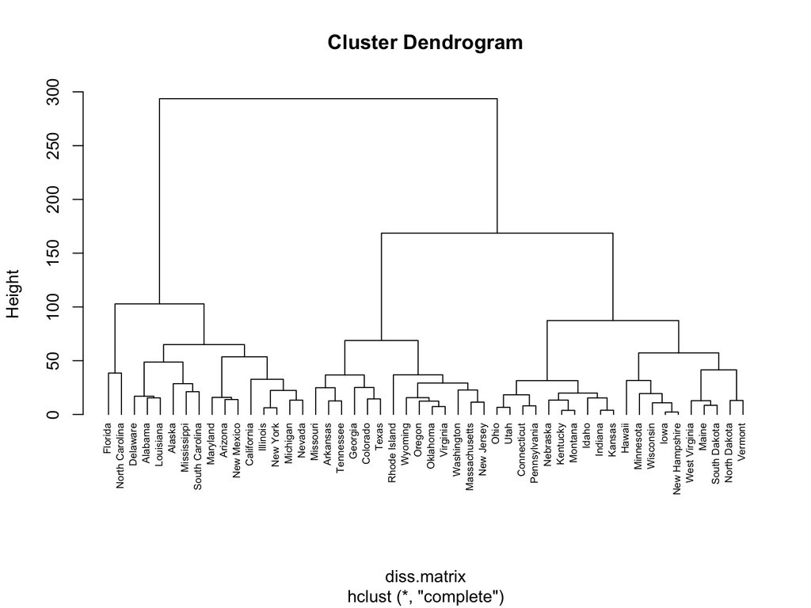

```r
# Create Dissimilarity matrix
diss.matrix <- dist(USArrests, method = "euclidean")
# Hierarchical clustering using Complete Linkage
hc_complete <- hclust(diss.matrix, method = "complete")
# Plot the obtained dendrogram
plot(hc_complete, cex = 0.6, hang = -1)
```

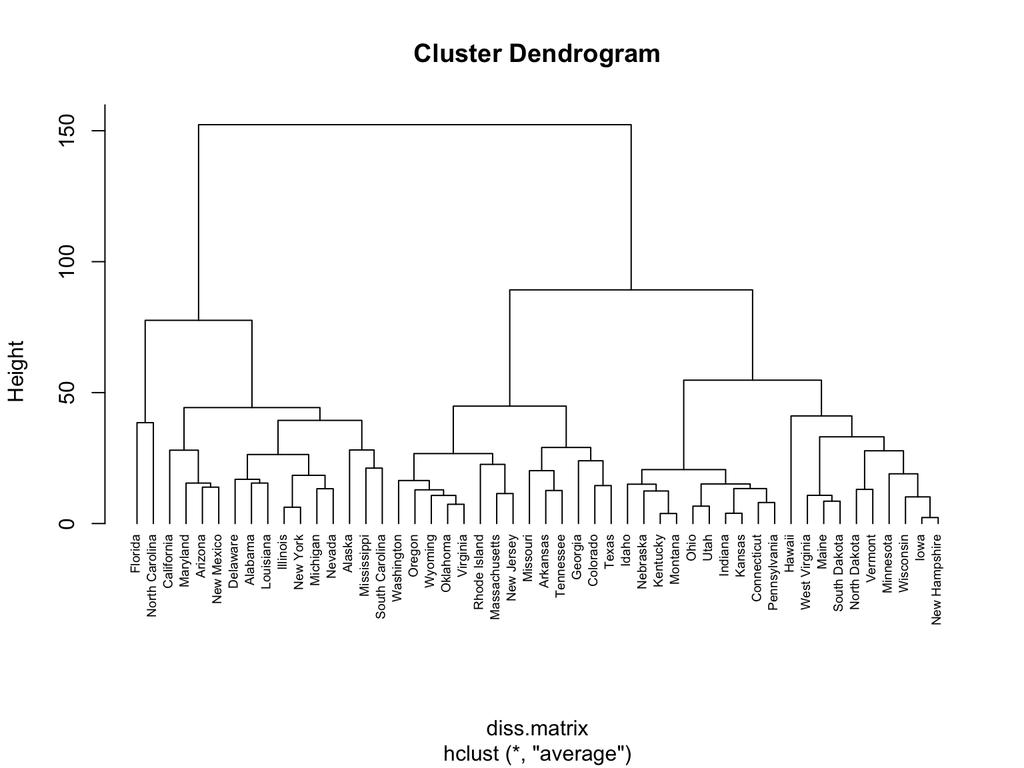

```r
# Hierarchical clustering using Average Linkage
hc_average <- hclust(diss.matrix, method = "average")
# Plot the obtained dendrogram
plot(hc_average, cex = 0.6, hang = -1)
```

#### Single Agglomeration Method

It computes all pairwise dissimilarities between the elements in cluster 1 and the elements in cluster 2, and considers the smallest of these dissimilarities as a linkage criterion. It tends to produce long, “loose” clusters.

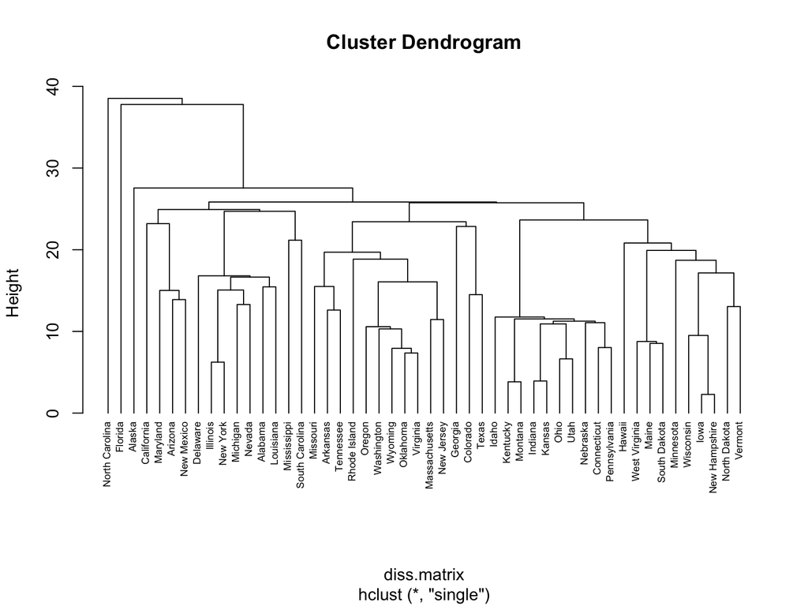

```r
# Hierarchical clustering using Single Linkage
hc_single <- hclust(diss.matrix, method = "single")
# Plot the obtained dendrogram
plot(hc_single, cex = 0.6, hang = -1)
```

#### Difference Between Dendrograms

It is noticeable to mention that the single agglomeration method produced the most clusters, while the average and complete agglomeration methods produced less and more compact clusters.

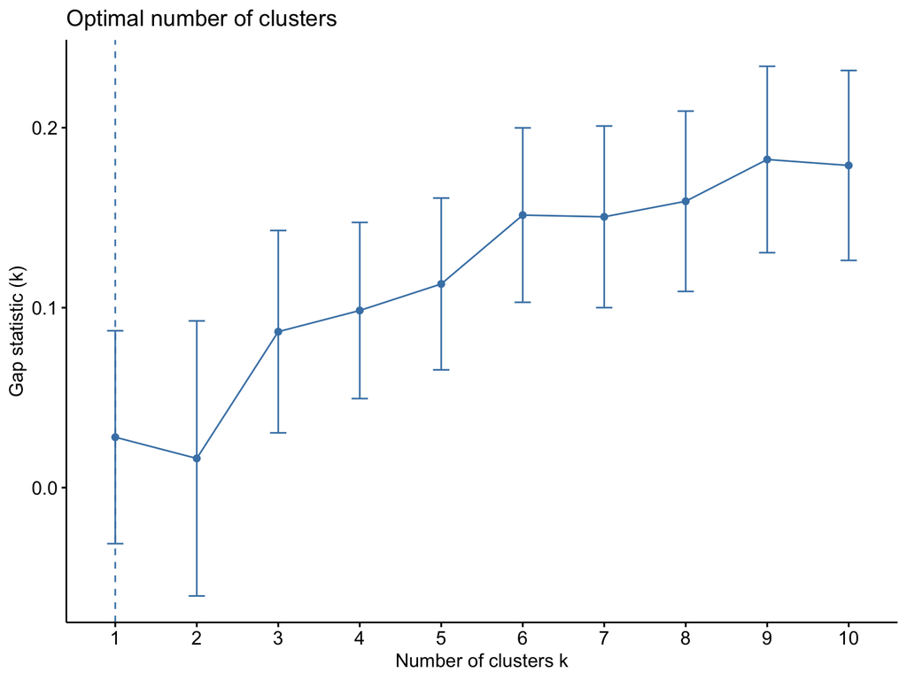

```r
clusGap(USArrests, FUN = hcut, nstart = 25, K.max = 10, B = 50) %>%
fviz_gap_stat()
```

#### Below, I describe one research question that can be addressed using the newly identified clusters.

What states should be prioritized to receive a community-based violence prevention intervention based on their rates of murder, assault, and rape.